# Untitled

2026-11-04

### 1.INTRODUCTION GÉNÉRALE

La sécurité routière constitue un enjeu majeur de santé publique et de société. Les accidents de la circulation entraînent chaque année des conséquences humaines, sociales et économiques importantes. Leur compréhension nécessite une analyse approfondie des circonstances dans lesquelles ils surviennent, ainsi que des caractéristiques des personnes et des véhicules impliqués.

Dans ce contexte, l’analyse statistique des données constitue un outil essentiel pour identifier les tendances, mettre en évidence les situations les plus fréquemment associées aux accidents et mieux comprendre les facteurs liés à leur gravité.

En France, les données relatives aux accidents corporels de la circulation sont notamment collectées dans les fichiers BAAC (Bulletins d’Analyse des Accidents Corporels de la circulation). Ces données fournissent des informations détaillées sur les caractéristiques des accidents, les lieux où ils se produisent, les usagers impliqués et les véhicules concernés.

Le présent projet porte sur l’analyse des accidents corporels de la route enregistrés en France au cours de l’année 2024, à partir des données BAAC. Il s’inscrit dans une démarche de Data Science visant à exploiter, préparer, analyser et valoriser des données réelles à l’aide de méthodes statistiques et d’outils informatiques.

*Problématique*

Dans quelle mesure l’analyse statistique des données BAAC 2024 permet-elle de caractériser la répartition des accidents corporels de la route en France selon leurs dimensions temporelles, géographiques, environnementales et humaines, ainsi que selon les véhicules impliqués ?

*Objectifs du projet*

Ce travail poursuit plusieurs objectifs : - Explorer et comprendre la structure des données BAAC 2024. - Nettoyer et préparer les différentes tables afin de construire une base analytique cohérente. - Étudier la répartition temporelle des accidents selon les mois, les jours et les heures. - Analyser leur distribution géographique et les conditions environnementales associées. - Étudier le profil des usagers impliqués selon l’âge, le sexe et la gravité des blessures. - Examiner les catégories de véhicules impliqués et leur association avec la gravité des accidents. - Concevoir un tableau de bord interactif avec R Shiny afin de faciliter l’exploration des résultats. Démarche méthodologique

Le projet repose sur une démarche structurée en plusieurs étapes : collecte et exploration des données, nettoyage et préparation des tables, analyse exploratoire, visualisation des résultats et développement d’une application interactive.

Les analyses sont réalisées principalement avec le langage R et ses bibliothèques dédiées à la manipulation, à l’analyse et à la visualisation des données.

### 2. Présentation des données

2.1. Source et origine des données

Les données utilisées dans cette étude proviennent de la base BAAC (Bulletins d’Analyse des Accidents Corporels de la circulation), qui recense les accidents corporels de la circulation routière enregistrés en France.

L’étude porte sur l’année 2024. Les fichiers exploités contiennent des informations relatives aux caractéristiques des accidents, à leur localisation, aux usagers impliqués et aux véhicules concernés.

Ces données permettent de réaliser une analyse descriptive multidimensionnelle des accidents corporels de la route.

### 2.2. Description des fichiers

L’analyse repose sur quatre fichiers complémentaires : Fichier Dimensions observées Contenu carac 54 402 lignes × 15 colonnes Caractéristiques générales des accidents lieux 70 248 lignes × 18 colonnes Informations relatives aux lieux et aux conditions de circulation usagers 125 187 lignes × 16 colonnes Informations sur les personnes impliquées vehicules 92 678 lignes × 11 colonnes Informations sur les véhicules impliqués

### 2.3. Structure et granularité des données

Les quatre fichiers ne possèdent pas la même granularité. - Le fichier carac constitue la table de référence pour les accidents : chaque ligne correspond à un accident identifié par Num_Acc. - Le fichier lieux peut contenir plusieurs enregistrements pour un même accident, comme le montre l’examen de l’accident 202400050330. - Le fichier usagers contient plusieurs lignes lorsqu’un accident implique plusieurs personnes. - Le fichier vehicules contient plusieurs lignes lorsqu’un accident implique plusieurs véhicules. Cette différence de granularité constitue un point important de la préparation des données. Une jointure directe de toutes les tables pourrait provoquer une multiplication artificielle des lignes et fausser les effectifs statistiques. ### 2.4. Choix de la base analytique Afin de conserver une observation par accident, le fichier carac est utilisé comme référence. Les informations relatives à la gravité des accidents sont agrégées à partir du fichier usagers, tandis que les informations relatives au nombre de véhicules sont calculées à partir du fichier vehicules.

Le fichier lieux est conservé séparément pour les analyses portant sur les caractéristiques géographiques et environnementales, compte tenu de ses enregistrements multiples pour certains accidents.

Cette organisation permet de distinguer les analyses réalisées au niveau de l’accident de celles réalisées au niveau de l’usager ou du véhicule.

*Chargement des fichiers*

```r
list.files("data")
```

```
## [1] "accidents_clean.rds"  "caract-2024.csv"      "lieux-2024.csv"
## [4] "synthese_globale.csv" "usagers-2024.csv"     "usagers_2024.rds"
## [7] "vehicules-2024.csv"   "vehicules_2024.rds"
```

```r
library(dplyr)
library(readr)
```

*Les pakages*

```r
install.packages(c("dplyr", "readr", "ggplot2", "lubridate",
                   "shiny", "plotly", "leaflet", "tidyr", "scales", "knitr"))
```

```r
setdiff(c("dplyr", "readr", "ggplot2", "lubridate", "shiny", "plotly", "leaflet"), rownames(installed.packages()))
```

```
## character(0)
```

*Noms des fichiers*

```r
f_carac <- list.files("data", pattern = "carac", full.names = TRUE)
f_lieux <- list.files("data", pattern = "lieux", full.names = TRUE)
f_usag <- list.files("data", pattern = "usagers.*\\.csv$",
                     full.names = TRUE, ignore.case = TRUE)
f_vehic <- list.files("data", pattern = "vehicules", full.names = TRUE)

f_carac; f_lieux; f_usag; f_vehic
```

```
## [1] "data/caract-2024.csv"
```

```
## [1] "data/lieux-2024.csv"
```

```
## [1] "data/usagers-2024.csv"
```

```
## [1] "data/vehicules-2024.csv" "data/vehicules_2024.rds"
```

*lecture des fichiers*

```r
library(dplyr)
library(readr)
carac <- read_delim(f_carac, delim = ";",
                    col_types = cols(Num_Acc = col_character()),
                    guess_max = Inf,
                    show_col_types = FALSE)

lieux <- read_delim(f_lieux, delim = ";",
                    col_types = cols(Num_Acc = col_character()),
                    guess_max = Inf,
                    show_col_types = FALSE)

usagers <- read_delim(f_usag, delim = ";",
                      col_types = cols(Num_Acc = col_character()),
                      guess_max = Inf,
                      show_col_types = FALSE)
```

*Analyse des dimensions*

```r
dim(carac)
```

```
## [1] 54402    15
```

```r
dim(usagers)
```

```
## [1] 125187     16
```

```r
dim(lieux)
```

```
## [1] 70248    18
```

*Observation*:

caractéristique (carac):54402 accidents enrégistrés (qui correspond au nombre de ligne)

lieux:70248 lignes,soit 15846 lignes de plus que carac

usagers:125187 lignes ,soit plusieurs usagers par accident en moyenne

Ainsi on constate que la table lieux contient plus de lignes que carac.

*Question*:le pourquoi?

*Nom des variables*

```r
names(carac)
```

```
##  [1] "Num_Acc" "jour"    "mois"    "an"      "hrmn"    "lum"     "dep"
##  [8] "com"     "agg"     "int"     "atm"     "col"     "adr"     "lat"
## [15] "long"
```

```r
names(usagers)
```

```
##  [1] "Num_Acc"     "id_usager"   "id_vehicule" "num_veh"     "place"
##  [6] "catu"        "grav"        "sexe"        "an_nais"     "trajet"
## [11] "secu1"       "secu2"       "secu3"       "locp"        "actp"
## [16] "etatp"
```

```r
names(lieux)
```

```
##  [1] "Num_Acc" "catr"    "voie"    "v1"      "v2"      "circ"    "nbv"
##  [8] "vosp"    "prof"    "pr"      "pr1"     "plan"    "lartpc"  "larrout"
## [15] "surf"    "infra"   "situ"    "vma"
```

*Affichage des tables*

```r
glimpse(carac)
```

```
## Rows: 54,402
## Columns: 15
## $ Num_Acc <chr> "202400000001", "202400000002", "202400000003", "202400000004"…
## $ jour    <dbl> 25, 20, 22, 24, 25, 25, 24, 24, 24, 25, 24, 24, 25, 25, 25, 25…
## $ mois    <chr> "03", "03", "03", "03", "03", "03", "03", "03", "03", "03", "0…
## $ an      <dbl> 2024, 2024, 2024, 2024, 2024, 2024, 2024, 2024, 2024, 2024, 20…
## $ hrmn    <time> 07:40:00, 15:05:00, 19:30:00, 17:50:00, 19:35:00, 04:00:00, 0…
## $ lum     <dbl> 2, 1, 2, 1, 5, 5, 5, 1, 3, 5, 2, 3, 1, 1, 1, 1, 1, 1, 1, 5, 1,…
## $ dep     <chr> "70", "21", "15", "14", "13", "13", "13", "07", "07", "06", "7…
## $ com     <chr> "70285", "21054", "15012", "14118", "13106", "13215", "13201",…
## $ agg     <dbl> 1, 2, 1, 2, 1, 2, 2, 2, 2, 2, 2, 2, 2, 2, 2, 2, 2, 2, 2, 2, 2,…
## $ int     <dbl> 1, 3, 1, 3, 3, 2, 1, 1, 1, 1, 1, 1, 1, 3, 3, 2, 3, 1, 2, 1, 2,…
## $ atm     <dbl> 5, 7, 1, 7, 2, 1, 1, 1, 1, 1, 1, 1, 1, 1, 1, 1, 1, 1, 1, 1, 1,…
## $ col     <chr> "1", "6", "6", "3", "5", "3", "3", "2", "6", "7", "2", "7", "6…
## $ adr     <chr> "D438", "HOTEL DIEU (RUE DE L')", "Allée des Tilleuls", "128 R…
## $ lat     <chr> "47,56277000", "47,02109000", "44,90238400", "49,19166000", "4…
## $ long    <chr> "6,75832000", "4,83755000", "2,49641800", " -0,39851000", "5,3…
```

```r
glimpse(usagers)
```

```
## Rows: 125,187
## Columns: 16
## $ Num_Acc     <chr> "202400000001", "202400000001", "202400000002", "202400000…
## $ id_usager   <chr> "203 988 581", "203 988 582", "203 988 579", "203 988 580"…
## $ id_vehicule <chr> "155 781 758", "155 781 759", "155 781 757", "155 781 757"…
## $ num_veh     <chr> "A01", "B01", "A01", "A01", "A01", "A01", "A01", "A01", "A…
## $ place       <chr> "1", "1", "10", "1", "2", "10", "10", "1", "10", "1", "1",…
## $ catu        <dbl> 1, 1, 3, 1, 2, 3, 3, 1, 3, 1, 1, 1, 1, 1, 1, 2, 2, 2, 2, 1…
## $ grav        <dbl> 3, 1, 3, 1, 4, 4, 3, 4, 1, 4, 4, 4, 1, 4, 4, 1, 1, 1, 1, 1…
## $ sexe        <chr> "1", "1", "2", "1", "2", "1", "2", "2", "1", "1", "1", "2"…
## $ an_nais     <dbl> 2003, 1997, 1927, 1987, 2007, 2007, 2008, 2007, 2007, 1963…
## $ trajet      <chr> "2", "4", "5", "4", "5", "5", "5", "5", "5", "5", "0", "0"…
## $ secu1       <chr> "1", "1", "0", "1", "8", "0", "0", "8", "0", "2", "8", "8"…
## $ secu2       <chr> " -1", " -1", " -1", "0", "0", " -1", " -1", "0", " -1", "…
## $ secu3       <chr> " -1", " -1", " -1", " -1", " -1", " -1", " -1", " -1", " …
## $ locp        <chr> " -1", " -1", "3", "3", " -1", "6", "6", " -1", "6", "0", …
## $ actp        <chr> " -1", " -1", "3", "3", " -1", "B", "B", " -1", "B", "0", …
## $ etatp       <chr> " -1", " -1", "1", "1", " -1", "3", "3", " -1", "3", " -1"…
```

```r
glimpse(lieux)
```

```
## Rows: 70,248
## Columns: 18
## $ Num_Acc <chr> "202400000001", "202400000002", "202400000002", "202400000003"…
## $ catr    <dbl> 3, 4, 4, 4, 4, 4, 1, 1, 4, 4, 6, 4, 4, 4, 4, 4, 4, 4, 4, 4, 4,…
## $ voie    <chr> "D438", "HOTEL DIEU (RUE DE L')", "POTERNE (RUE)", "TILLEULS (…
## $ v1      <chr> "0", "0", "0", "0", "0", "0", "0", "0", "0", "0", "0", "0", "0…
## $ v2      <chr> "N/A", "N/A", "N/A", "N/A", "N/A", "N/A", "N/A", "N/A", "N/A",…
## $ circ    <chr> "2", "2", "1", "2", "2", "2", "2", "2", "2", "2", "2", "2", "2…
## $ nbv     <chr> "2", "2", "1", "2", "4", "2", "4", "4", "0", "3", "2", "2", "1…
## $ vosp    <chr> "0", "0", "0", "0", "0", "0", "0", "1", "0", "0", "0", "0", "0…
## $ prof    <chr> "1", "1", "1", "1", "1", "1", "1", "2", "1", "2", "1", "1", "1…
## $ pr      <chr> "1", " -1", " -1", " -1", " -1", " -1", "1", "272", "0", "0", …
## $ pr1     <chr> "260", " -1", " -1", " -1", " -1", " -1", "0", "0", "0", "0", …
## $ plan    <chr> "2", "1", "1", "1", "1", "1", "1", "1", "1", "1", "2", "1", "2…
## $ lartpc  <dbl> NA, NA, NA, NA, NA, NA, NA, NA, NA, NA, NA, NA, NA, NA, NA, NA…
## $ larrout <chr> "7", " -1", " -1", " -1", " -1", " -1", "17", "17", " -1", " -…
## $ surf    <chr> "1", "9", "9", "1", "1", "1", "2", "2", "1", "1", "1", "1", "1…
## $ infra   <chr> "0", "0", "0", "0", "9", "0", "0", "0", "5", "5", "9", "0", "0…
## $ situ    <chr> "1", "1", "1", "3", "1", "1", "1", "1", "1", "1", "1", "1", "3…
## $ vma     <chr> "90", "30", "30", "50", "50", "50", "50", "70", "50", "50", "5…
```

*Regardons pourquoi la table lieux contient plus de lignes que la table carac*

*Verification des doublons*

```r
# Nombre de Num_Acc distincts
n_distinct(carac$Num_Acc)
```

```
## [1] 54402
```

```r
n_distinct(lieux$Num_Acc)
```

```
## [1] 54402
```

```r
n_distinct(usagers$Num_Acc)
```

```
## [1] 54402
```

```r
# Nombre de doublons
sum(duplicated(carac$Num_Acc))
```

```
## [1] 0
```

```r
sum(duplicated(lieux$Num_Acc))
```

```
## [1] 15846
```

```r
sum(duplicated(usagers$Num_Acc))
```

```
## [1] 70785
```

*Conclusion*: -carac : pas de doublon (zéro) - lieux : plusieurs enregistrements peuvent correspondre au même accident. - usagers : plusieurs personnes peuvent être impliquées dans un même accident.

Donc la table carac constitue notre référence pour le nombre d’accidents. Les tables lieux et usagers nécessitent une attention particulière avant les jointures.

*Verification s’il existe des identifiant manquants*

```r
# Vérifier les identifiants manquants
sum(is.na(carac$Num_Acc))
```

```
## [1] 0
```

```r
sum(is.na(lieux$Num_Acc))
```

```
## [1] 0
```

```r
sum(is.na(usagers$Num_Acc))
```

```
## [1] 0
```

Pas de valeur manquante

```r
# Examiner les doublons dans lieux
lieux |>
  count(Num_Acc) |>
  filter(n > 1) |>
  arrange(desc(n))
```

```
## # A tibble: 15,645 × 2
##    Num_Acc          n
##    <chr>        <int>
##  1 202400050330     5
##  2 202400005122     4
##  3 202400005927     4
##  4 202400012290     4
##  5 202400012979     4
##  6 202400013470     4
##  7 202400017817     4
##  8 202400017969     4
##  9 202400018846     4
## 10 202400019378     4
## # ℹ 15,635 more rows
```

On constate plusieurs duplication d’enregistrement dans la table lieux Donc on examine d’ou provient ces duplications.

*Examen d’un accident*

```r
#Prenons l'accident numero 202400050330 qui possede 5 lignes par example
lieux |>
  filter(Num_Acc == "202400050330") |>
  glimpse()
```

```
## Rows: 5
## Columns: 18
## $ Num_Acc <chr> "202400050330", "202400050330", "202400050330", "202400050330"…
## $ catr    <dbl> 4, 4, 4, 4, 4
## $ voie    <chr> "PLACE D ALLERAY", "RUE BRANCION", "RUE D ALLERAY", "RUE DUTOT…
## $ v1      <chr> "0", "0", "0", "0", "0"
## $ v2      <chr> "N/A", "N/A", "N/A", "N/A", "N/A"
## $ circ    <chr> "2", "2", "1", "1", "2"
## $ nbv     <chr> "5", "2", "1", "1", "2"
## $ vosp    <chr> "0", "0", "0", "0", "0"
## $ prof    <chr> "1", "2", "1", "1", "2"
## $ pr      <chr> " -1", "0", "0", "0", " -1"
## $ pr1     <chr> " -1", "0", "0", "0", " -1"
## $ plan    <chr> "1", "1", "1", "1", "1"
## $ lartpc  <dbl> NA, NA, NA, NA, NA
## $ larrout <chr> " -1", " -1", " -1", " -1", " -1"
## $ surf    <chr> "1", "1", "1", "1", "1"
## $ infra   <chr> "0", "0", "0", "0", "0"
## $ situ    <chr> "1", "8", "8", "8", "8"
## $ vma     <chr> "30", "30", "30", "30", "30"
```

```r
lieux |>
  filter(Num_Acc == "202400050330") |>
  select(Num_Acc, everything())
```

```
## # A tibble: 5 × 18
##   Num_Acc       catr voie  v1    v2    circ  nbv   vosp  prof  pr    pr1   plan
##   <chr>        <dbl> <chr> <chr> <chr> <chr> <chr> <chr> <chr> <chr> <chr> <chr>
## 1 202400050330     4 PLAC… 0     N/A   2     5     0     1     " -1" " -1" 1
## 2 202400050330     4 RUE … 0     N/A   2     2     0     2     "0"   "0"   1
## 3 202400050330     4 RUE … 0     N/A   1     1     0     1     "0"   "0"   1
## 4 202400050330     4 RUE … 0     N/A   1     1     0     1     "0"   "0"   1
## 5 202400050330     4 RUE … 0     N/A   2     2     0     2     " -1" " -1" 1
## # ℹ 6 more variables: lartpc <dbl>, larrout <chr>, surf <chr>, infra <chr>,
## #   situ <chr>, vma <chr>
```

*comparaison automatique des 5 lignes*

```r
test_lieux <- lieux |>
  filter(Num_Acc == "202400050330")

# Nombre de lignes
nrow(test_lieux)
```

```
## [1] 5
```

```r
# Nombre de lignes strictement distinctes
nrow(distinct(test_lieux))
```

```
## [1] 5
```

```r
# Comparaison des lignes
all(duplicated(test_lieux)[-1])
```

```
## [1] FALSE
```

Observation: 5 enrégistrements 5 lignes sont differents Elles ne sont pas toutes des doublons

Donc pas besoin de supprimer ces lignes

*Identification des colonnes qui changent(variables qui changent)*

```
*comparaison précis de ces 5 enrégistrements*
```

```r
test_lieux |>
  summarise(
    across(
      everything(),
      ~ n_distinct(.x, na.rm = FALSE)
    )
  )
```

```
## # A tibble: 1 × 18
##   Num_Acc  catr  voie    v1    v2  circ   nbv  vosp  prof    pr   pr1  plan
##     <int> <int> <int> <int> <int> <int> <int> <int> <int> <int> <int> <int>
## 1       1     1     5     1     1     2     3     1     2     2     2     1
## # ℹ 6 more variables: lartpc <int>, larrout <int>, surf <int>, infra <int>,
## #   situ <int>, vma <int>
```

Les resultats montrent que ces 5 lignes ne sont pas des doublons technique mais plutot elles contiennet des informations differentes.

Plusieurs enrégistrement décrivent des caractéristique de lieux different pour un meme accident

*Examinons les 5 valeur de voie ainsi que les autres variables qui changent*

```r
test_lieux |>
  select(
    Num_Acc,
    voie,
    circ,
    nbv,
    prof,
    pr,
    pr1,
    situ
  )
```

```
## # A tibble: 5 × 8
##   Num_Acc      voie             circ  nbv   prof  pr    pr1   situ
##   <chr>        <chr>            <chr> <chr> <chr> <chr> <chr> <chr>
## 1 202400050330 PLACE D ALLERAY  2     5     1     " -1" " -1" 1
## 2 202400050330 RUE BRANCION     2     2     2     "0"   "0"   8
## 3 202400050330 RUE D ALLERAY    1     1     1     "0"   "0"   8
## 4 202400050330 RUE DUTOT        1     1     1     "0"   "0"   8
## 5 202400050330 RUE PAUL BARRUEL 2     2     2     " -1" " -1" 8
```

On constate que les informations relatives à la configuration routière varient d’une ligne à l’autre. Cela peut correspondre à un accident situé dans une zone complexe, avec plusieurs voies ou branches de circulation renseignées. Voir le doc(BAAC) sur le site

*Vérification de la table usagers*

```r
# Examinons les usagers d'un même accident
usagers |>
  filter(Num_Acc == "202400050330") |>
  select(Num_Acc, catu, grav, sexe, an_nais)
```

```
## # A tibble: 2 × 5
##   Num_Acc       catu  grav sexe  an_nais
##   <chr>        <dbl> <dbl> <chr>   <dbl>
## 1 202400050330     1     4 1        1974
## 2 202400050330     1     1 1        2000
```

```r
# Nombre d'usagers pour cet accident
usagers |>
  filter(Num_Acc == "202400050330") |>
  summarise(nb_usagers = n())
```

```
## # A tibble: 1 × 1
##   nb_usagers
##        <int>
## 1          2
```

on constate que 2 personnes sont impliquées dans un meme accident d’ou la répétition sur la table usagers.

*Construction de la table de gravité par accident(grav_acc)*

*l’idée* : si deux personnes sont impliquées dans un accident et qu’une seule est hospitalisée alors l’accident sera classé comme grave

```r
grav_acc <- usagers |>
  group_by(Num_Acc) |>
  summarise(
    nb_usagers = n(),
    grave = any(grav %in% c(2, 3)),
    tue = any(grav == 2),
    .groups = "drop"
  )
```

```r
# Dimensions
dim(grav_acc)
```

```
## [1] 54402     4
```

```r
# Nombre d'accidents distincts
n_distinct(grav_acc$Num_Acc)
```

```
## [1] 54402
```

```r
# Répartition des accidents graves
table(grav_acc$grave, useNA = "ifany")
```

```
##
## FALSE  TRUE
## 34744 19658
```

```r
# Nombre d'accidents avec au moins un tué
sum(grav_acc$tue, na.rm = TRUE)
```

```
## [1] 3226
```

54402 accidents distincts 19658 accidents graves(36,13%) 3226 accidents avec au moins un tué 34744 accidents classé non graves(63,87%) Ces chiffres décrivent les accidents corporels enregistrés dans la base 2024, et non l’ensemble des accidents de circulation.

```r
names(grav_acc)
```

```
## [1] "Num_Acc"    "nb_usagers" "grave"      "tue"
```

*Construction de la table accidents* Jointure

```r
accidents <- carac |>
  left_join(lieux, by = "Num_Acc") |>
  left_join(grav_acc, by = "Num_Acc")
```

*Verification de la dimension*

```r
# Nombre de lignes après jointure
nrow(accidents)
```

```
## [1] 70248
```

```r
# Nombre d'accidents distincts
n_distinct(accidents$Num_Acc)
```

```
## [1] 54402
```

```r
# Vérifier les doublons
sum(duplicated(accidents$Num_Acc))
```

```
## [1] 15846
```

```r
# Vérifier la structure
dim(accidents)
```

```
## [1] 70248    35
```

```r
names(accidents)
```

```
##  [1] "Num_Acc"    "jour"       "mois"       "an"         "hrmn"
##  [6] "lum"        "dep"        "com"        "agg"        "int"
## [11] "atm"        "col"        "adr"        "lat"        "long"
## [16] "catr"       "voie"       "v1"         "v2"         "circ"
## [21] "nbv"        "vosp"       "prof"       "pr"         "pr1"
## [26] "plan"       "lartpc"     "larrout"    "surf"       "infra"
## [31] "situ"       "vma"        "nb_usagers" "grave"      "tue"
```

accident :15846 doublons Remarque: cette jointure marche techniquement mais ne respecte pas encore l’objectif. C’est à dire:une ligne par accident

*Construction d’une table lieux_acc* verification d’abord

```r
# Répartition du nombre de lignes par accident dans lieux
lieux |>
  count(Num_Acc, name = "nb_lieux") |>
  count(nb_lieux, name = "nb_accidents") |>
  arrange(nb_lieux)
```

```
## # A tibble: 5 × 2
##   nb_lieux nb_accidents
##      <int>        <int>
## 1        1        38757
## 2        2        15463
## 3        3          164
## 4        4           17
## 5        5            1
```

*Interprétation* : 38 757 accidents ont une seule ligne dans lieux, tandis que les autres en ont plusieurs. Ces lignes ne sont pas nécessairement des doublons : nous avons déjà vérifié qu’elles peuvent contenir des informations différentes.

*Construction de la table au niveau accident* Pour respecter l’objectif d’avoir une seule ligne par accident, on va d’abord joindre carac et grav_acc. on gardera lieux séparément pour les analyses liées aux routes.

```r
accidents <- carac |>
  left_join(grav_acc, by = "Num_Acc")
```

```r
dim(accidents)
```

```
## [1] 54402    18
```

```r
n_distinct(accidents$Num_Acc)
```

```
## [1] 54402
```

```r
sum(duplicated(accidents$Num_Acc))
```

```
## [1] 0
```

- 54 402 lignes : nombre total d’accidents.
- 18 colonnes : variables de caractéristiques et indicateurs de gravité.
- 54 402 identifiants distincts.
- 0 doublon sur Num_Acc. Objectif une ligne par accident est atteint.

```r
glimpse(accidents)
```

```
## Rows: 54,402
## Columns: 18
## $ Num_Acc    <chr> "202400000001", "202400000002", "202400000003", "2024000000…
## $ jour       <dbl> 25, 20, 22, 24, 25, 25, 24, 24, 24, 25, 24, 24, 25, 25, 25,…
## $ mois       <chr> "03", "03", "03", "03", "03", "03", "03", "03", "03", "03",…
## $ an         <dbl> 2024, 2024, 2024, 2024, 2024, 2024, 2024, 2024, 2024, 2024,…
## $ hrmn       <time> 07:40:00, 15:05:00, 19:30:00, 17:50:00, 19:35:00, 04:00:00…
## $ lum        <dbl> 2, 1, 2, 1, 5, 5, 5, 1, 3, 5, 2, 3, 1, 1, 1, 1, 1, 1, 1, 5,…
## $ dep        <chr> "70", "21", "15", "14", "13", "13", "13", "07", "07", "06",…
## $ com        <chr> "70285", "21054", "15012", "14118", "13106", "13215", "1320…
## $ agg        <dbl> 1, 2, 1, 2, 1, 2, 2, 2, 2, 2, 2, 2, 2, 2, 2, 2, 2, 2, 2, 2,…
## $ int        <dbl> 1, 3, 1, 3, 3, 2, 1, 1, 1, 1, 1, 1, 1, 3, 3, 2, 3, 1, 2, 1,…
## $ atm        <dbl> 5, 7, 1, 7, 2, 1, 1, 1, 1, 1, 1, 1, 1, 1, 1, 1, 1, 1, 1, 1,…
## $ col        <chr> "1", "6", "6", "3", "5", "3", "3", "2", "6", "7", "2", "7",…
## $ adr        <chr> "D438", "HOTEL DIEU (RUE DE L')", "Allée des Tilleuls", "12…
## $ lat        <chr> "47,56277000", "47,02109000", "44,90238400", "49,19166000",…
## $ long       <chr> "6,75832000", "4,83755000", "2,49641800", " -0,39851000", "…
## $ nb_usagers <int> 2, 2, 5, 1, 4, 6, 5, 2, 5, 1, 7, 1, 2, 2, 2, 3, 2, 2, 2, 2,…
## $ grave      <lgl> TRUE, TRUE, TRUE, FALSE, FALSE, FALSE, TRUE, FALSE, FALSE, …
## $ tue        <lgl> FALSE, FALSE, FALSE, FALSE, FALSE, FALSE, FALSE, FALSE, FAL…
```

*Verification des valeurs manquantes*

```r
colSums(is.na(accidents))
```

```
##    Num_Acc       jour       mois         an       hrmn        lum        dep
##          0          0          0          0          0          0          0
##        com        agg        int        atm        col        adr        lat
##          0          0          0          0          0          2          0
##       long nb_usagers      grave        tue
##          0          0          0          0
```

on constate qu’il y’a 2 valeur manquantes sur 54402 accidents

*Vérification d’ou ça provient les 2 valeurs manquantes*

```r
accidents |>
  filter(is.na(adr)) |>
  select(Num_Acc, everything())
```

```
## # A tibble: 2 × 18
##   Num_Acc       jour mois     an hrmn    lum dep   com     agg   int   atm col
##   <chr>        <dbl> <chr> <dbl> <tim> <dbl> <chr> <chr> <dbl> <dbl> <dbl> <chr>
## 1 202400000189    12 08     2024 11:45     1 972   97213     1     1     3 2
## 2 202400004432    27 04     2024 10:00     1 972   97213     2     4     1 3
## # ℹ 6 more variables: adr <chr>, lat <chr>, long <chr>, nb_usagers <int>,
## #   grave <lgl>, tue <lgl>
```

La colonne adr (adresse) est manquante pour ces deux observations dont Num_Acc (202400000189) et (202400004432). En revanche, nous avons des coordonnées géographiques pour le premier accident (202400000189) : latitude 14,61523000 et longitude -61,01390000.

Décision : on conserve les deux accidents. Il ne faut ni supprimer ces lignes ni remplacer arbitrairement les adresses manquantes.

*Vérication des types de variables*

```r
str(accidents)
```

```
## spc_tbl_ [54,402 × 18] (S3: spec_tbl_df/tbl_df/tbl/data.frame)
##  $ Num_Acc   : chr [1:54402] "202400000001" "202400000002" "202400000003" "202400000004" ...
##  $ jour      : num [1:54402] 25 20 22 24 25 25 24 24 24 25 ...
##  $ mois      : chr [1:54402] "03" "03" "03" "03" ...
##  $ an        : num [1:54402] 2024 2024 2024 2024 2024 ...
##  $ hrmn      : 'hms' num [1:54402] 07:40:00 15:05:00 19:30:00 17:50:00 ...
##   ..- attr(*, "units")= chr "secs"
##  $ lum       : num [1:54402] 2 1 2 1 5 5 5 1 3 5 ...
##  $ dep       : chr [1:54402] "70" "21" "15" "14" ...
##  $ com       : chr [1:54402] "70285" "21054" "15012" "14118" ...
##  $ agg       : num [1:54402] 1 2 1 2 1 2 2 2 2 2 ...
##  $ int       : num [1:54402] 1 3 1 3 3 2 1 1 1 1 ...
##  $ atm       : num [1:54402] 5 7 1 7 2 1 1 1 1 1 ...
##  $ col       : chr [1:54402] "1" "6" "6" "3" ...
##  $ adr       : chr [1:54402] "D438" "HOTEL DIEU (RUE DE L')" "Allée des Tilleuls" "128 Rue d'Authie" ...
##  $ lat       : chr [1:54402] "47,56277000" "47,02109000" "44,90238400" "49,19166000" ...
##  $ long      : chr [1:54402] "6,75832000" "4,83755000" "2,49641800" " -0,39851000" ...
##  $ nb_usagers: int [1:54402] 2 2 5 1 4 6 5 2 5 1 ...
##  $ grave     : logi [1:54402] TRUE TRUE TRUE FALSE FALSE FALSE ...
##  $ tue       : logi [1:54402] FALSE FALSE FALSE FALSE FALSE FALSE ...
##  - attr(*, "spec")=
##   .. cols(
##   ..   Num_Acc = col_character(),
##   ..   jour = col_double(),
##   ..   mois = col_character(),
##   ..   an = col_double(),
##   ..   hrmn = col_time(format = ""),
##   ..   lum = col_double(),
##   ..   dep = col_character(),
##   ..   com = col_character(),
##   ..   agg = col_double(),
##   ..   int = col_double(),
##   ..   atm = col_double(),
##   ..   col = col_character(),
##   ..   adr = col_character(),
##   ..   lat = col_character(),
##   ..   long = col_character()
##   .. )
##  - attr(*, "problems")=<pointer: 0x000001e69b2ffdc0>
```

*Véification des valeurs particulières(pour les variables numeriques)*

```r
accidents |>
  summarise(
    across(
      where(is.numeric),
      ~ sum(.x == -1, na.rm = TRUE)
    )
  )
```

```
## # A tibble: 1 × 7
##    jour    an   lum   agg   int   atm nb_usagers
##   <int> <int> <int> <int> <int> <int>      <int>
## 1     0     0     0     0     0     0          0
```

*Vérification des codes -1 dans les variables qualitatives*

```r
accidents |>
  summarise(
    across(
      where(is.character),
      ~ sum(.x == "-1", na.rm = TRUE)
    )
  )
```

```
## # A tibble: 1 × 8
##   Num_Acc  mois   dep   com   col   adr   lat  long
##     <int> <int> <int> <int> <int> <int> <int> <int>
## 1       0     0     0     0     0     0     0     0
```

On a donc vérifié : - Les valeurs manquantes (NA) : seulement 2 dans adr. - Les codes -1 : aucun dans les variables numériques et caractères examinées. - Les identifiants Num_Acc : aucune duplication dans notre table accidents.

*Vérification des doublons complets*

```r
sum(duplicated(accidents))
```

```
## [1] 0
```

Pour la table accidents on a: 54 402 accidents. 54 402 identifiants uniques. 0 doublon complet. 2 valeurs manquantes dans adr. Aucun code -1 détecté.

*Préparation des variables temporelles* On va créer une véritable variable de date à partir de jour,mois et an puis une variable permettant d’exploiter l’heure des accidents.

```r
library(lubridate)
library(dplyr)

accidents <- accidents |>
  mutate(
    date = make_date(
      year = an,
      month = as.integer(mois),
      day = jour
    ),
    heure = hour(hrmn),
    minute = minute(hrmn)
  )
```

```r
head(accidents |> select(Num_Acc, jour, mois, an, date, hrmn, heure, minute))
```

```
## # A tibble: 6 × 8
##   Num_Acc       jour mois     an date       hrmn   heure minute
##   <chr>        <dbl> <chr> <dbl> <date>     <time> <int>  <int>
## 1 202400000001    25 03     2024 2024-03-25 07:40      7     40
## 2 202400000002    20 03     2024 2024-03-20 15:05     15      5
## 3 202400000003    22 03     2024 2024-03-22 19:30     19     30
## 4 202400000004    24 03     2024 2024-03-24 17:50     17     50
## 5 202400000005    25 03     2024 2024-03-25 19:35     19     35
## 6 202400000006    25 03     2024 2024-03-25 04:00      4      0
```

*Création des tranches horaires*

Pour l’analyse des accidents selon les heures de la journée, on va créer quatre périodes: 1. Nuit : 00h–05h59 2. Matin : 06h–11h59 3. Après-midi : 12h–17h59 4. Soir : 18h–23h59

```r
accidents <- accidents |>
  mutate(
    periode = case_when(
      heure >= 0 & heure < 6  ~ "Nuit",
      heure >= 6 & heure < 12 ~ "Matin",
      heure >= 12 & heure < 18 ~ "Après-midi",
      heure >= 18 & heure < 24 ~ "Soir"
    )
  )
```

```r
table(accidents$periode)
```

```
##
## Après-midi      Matin       Nuit       Soir
##      20098      14540       5048      14716
```

*Première observation* : l’après-midi concentre le plus grand nombre d’accidents dans notre jeu de données, avec environ 36,9 %. La nuit présente le plus faible effectif.

ce sont des nombres d’accidents, pas des taux de risque rapportés au trafic.

*Préparation des classes d’age* On va maintenant travailler sur la table usagers, car l’âge des personnes impliquées n’est pas dans la table accidents.

```r
names(usagers)
```

```
##  [1] "Num_Acc"     "id_usager"   "id_vehicule" "num_veh"     "place"
##  [6] "catu"        "grav"        "sexe"        "an_nais"     "trajet"
## [11] "secu1"       "secu2"       "secu3"       "locp"        "actp"
## [16] "etatp"
```

Ainsi pour connaitre l’age des usagers on va calculer l’année de l’accident(2024) et l’année de naissance de chaque usagers

*Calcul de l’age des usagers*

```r
usagers <- usagers |>
  mutate(
    age = 2024 - an_nais
  )
```

```r
head(usagers |> select(Num_Acc, sexe, an_nais, age))
```

```
## # A tibble: 6 × 4
##   Num_Acc      sexe  an_nais   age
##   <chr>        <chr>   <dbl> <dbl>
## 1 202400000001 1        2003    21
## 2 202400000001 1        1997    27
## 3 202400000002 2        1927    97
## 4 202400000002 1        1987    37
## 5 202400000003 2        2007    17
## 6 202400000003 1        2007    17
```

*Controle de l’age* on verifie s’il y’a des valeurs manquantes et les ages min et max

```r
summary(usagers$age)
```

```
##    Min. 1st Qu.  Median    Mean 3rd Qu.    Max.     NAs
##    0.00   23.00   36.00   38.92   53.00  110.00    2579
```

```r
sum(is.na(usagers$age))
```

```
## [1] 2579
```

```r
sum(usagers$age < 0, na.rm = TRUE)
```

```
## [1] 0
```

- Âge minimum : 0 an.
- Âge maximum : 110 ans.
- Âge moyen : 38,92 ans.
- Âge médian : 36 ans.
- Valeurs manquantes : 2 579.
- Âges négatifs : 0. Les 2 579 valeurs manquantes représentent environ 2,06 % des 125 187 usagers.

Création de la classe d’age:

Classe Tranche d’âge Enfants Moins de 15 ans Adolescents 15–17 ans Jeunes adultes 18–24 ans Adultes 25–44 ans Adultes mûrs 45–64 ans Seniors 65 ans et plus

```r
usagers <- usagers |>
  mutate(
    classe_age = case_when(
      age < 15 ~ "Enfants",
      age <= 17 ~ "Adolescents",
      age <= 24 ~ "Jeunes adultes",
      age <= 44 ~ "Adultes",
      age <= 64 ~ "Adultes mûrs",
      age >= 65 ~ "Seniors",
      TRUE ~ NA_character_
    )
  )
```

```r
table(usagers$classe_age, useNA = "ifany")
```

```
##
##    Adolescents        Adultes   Adultes mûrs        Enfants Jeunes adultes
##           4790          43745          29729           6657          23366
##        Seniors           <NA>
##          14321           2579
```

*Observation* : les adultes de 25 à 44 ans constituent la catégorie la plus représentée parmi les usagers recensés.

ces effectifs concernent les personnes impliquées, pas le nombre d’accidents.

*Agregation des informations des usagers par accident*

*Objectif*: c’est de rattacher les informations sur les usagers à la table accidents, qui contient une seule ligne par accident.

On va d’abord calculer le nombre d’usagers par classe d’âge pour chaque accident.

```r
age_acc <- usagers |>
  filter(!is.na(classe_age)) |>
  count(Num_Acc, classe_age) |>
  tidyr::pivot_wider(
    names_from = classe_age,
    values_from = n,
    values_fill = 0,
    names_prefix = "nb_"
  )
```

```r
dim(age_acc)
```

```
## [1] 54402     7
```

```r
n_distinct(age_acc$Num_Acc)
```

```
## [1] 54402
```

```r
head(age_acc)
```

```
## # A tibble: 6 × 7
##   Num_Acc      nb_Adultes `nb_Jeunes adultes` nb_Seniors nb_Adolescents
##   <chr>             <int>               <int>      <int>          <int>
## 1 202400000001          1                   1          0              0
## 2 202400000002          1                   0          1              0
## 3 202400000003          0                   0          0              5
## 4 202400000004          0                   0          0              0
## 5 202400000005          1                   2          0              0
## 6 202400000006          4                   0          0              1
## # ℹ 2 more variables: `nb_Adultes mûrs` <int>, nb_Enfants <int>
```

- 54 402 lignes
- 54 402 accidents distincts
- 7 colonnes : l’identifiant Num_Acc et les six classes d’âge. La table contient donc une seule ligne par accident. Chaque colonne nb_… indique le nombre d’usagers appartenant à une classe d’âge pour cet accident.

Par exemple, pour 202400000005 : - 1 adulte ; - 2 jeunes adultes ; - 1 adulte mûr ; - aucun adolescent ni senior. - aucun enfant

*Jointure des informations d’age à l’accidents*

```r
accidents <- accidents |>
  left_join(age_acc, by = "Num_Acc")
```

```r
dim(accidents)
```

```
## [1] 54402    28
```

```r
n_distinct(accidents$Num_Acc)
```

```
## [1] 54402
```

```r
sum(duplicated(accidents$Num_Acc))
```

```
## [1] 0
```

```r
colSums(is.na(accidents))
```

```
##           Num_Acc              jour              mois                an
##                 0                 0                 0                 0
##              hrmn               lum               dep               com
##                 0                 0                 0                 0
##               agg               int               atm               col
##                 0                 0                 0                 0
##               adr               lat              long        nb_usagers
##                 2                 0                 0                 0
##             grave               tue              date             heure
##                 0                 0                 0                 0
##            minute           periode        nb_Adultes nb_Jeunes adultes
##                 0                 0                 0                 0
##        nb_Seniors    nb_Adolescents   nb_Adultes mûrs        nb_Enfants
##                 0                 0                 0                 0
```

```r
names(accidents)
```

```
##  [1] "Num_Acc"           "jour"              "mois"
##  [4] "an"                "hrmn"              "lum"
##  [7] "dep"               "com"               "agg"
## [10] "int"               "atm"               "col"
## [13] "adr"               "lat"               "long"
## [16] "nb_usagers"        "grave"             "tue"
## [19] "date"              "heure"             "minute"
## [22] "periode"           "nb_Adultes"        "nb_Jeunes adultes"
## [25] "nb_Seniors"        "nb_Adolescents"    "nb_Adultes mûrs"
## [28] "nb_Enfants"
```

```r
sum(accidents$nb_Adultes.x != accidents$nb_Adultes.y)
```

```
## [1] 0
```

```r
sum(accidents$nb_Adultes.x != accidents$nb_Adultes)
```

```
## [1] 0
```

```r
sum(accidents$`nb_Jeunes adultes.x` != accidents$`nb_Jeunes adultes.y`)
```

```
## [1] 0
```

```r
sum(accidents$`nb_Jeunes adultes.x` != accidents$`nb_Jeunes adultes`)
```

```
## [1] 0
```

```r
sum(accidents$nb_Seniors.x != accidents$nb_Seniors.y)
```

```
## [1] 0
```

```r
sum(accidents$nb_Seniors.x != accidents$nb_Seniors)
```

```
## [1] 0
```

```r
sum(accidents$nb_Adolescents.x != accidents$nb_Adolescents.y)
```

```
## [1] 0
```

```r
sum(accidents$nb_Adolescents.x != accidents$nb_Adolescents)
```

```
## [1] 0
```

```r
sum(accidents$`nb_Adultes mûrs.x` != accidents$`nb_Adultes mûrs.y`)
```

```
## [1] 0
```

```r
sum(accidents$`nb_Adultes mûrs.x` != accidents$`nb_Adultes mûrs`)
```

```
## [1] 0
```

```r
sum(accidents$nb_Enfants.x != accidents$nb_Enfants.y)
```

```
## [1] 0
```

```r
sum(accidents$nb_Enfants.x != accidents$nb_Enfants)
```

```
## [1] 0
```

*La table accident à garder*

```r
accidents <- accidents |>
  select(-ends_with(".x"), -ends_with(".y"))
```

```r
dim(accidents)
```

```
## [1] 54402    28
```

```r
names(accidents)
```

```
##  [1] "Num_Acc"           "jour"              "mois"
##  [4] "an"                "hrmn"              "lum"
##  [7] "dep"               "com"               "agg"
## [10] "int"               "atm"               "col"
## [13] "adr"               "lat"               "long"
## [16] "nb_usagers"        "grave"             "tue"
## [19] "date"              "heure"             "minute"
## [22] "periode"           "nb_Adultes"        "nb_Jeunes adultes"
## [25] "nb_Seniors"        "nb_Adolescents"    "nb_Adultes mûrs"
## [28] "nb_Enfants"
```

```r
sum(duplicated(accidents$Num_Acc))
```

```
## [1] 0
```

*Vérifions que si tout est en ordre*

```r
accidents |>
  select(
    Num_Acc,
    nb_Enfants,
    `nb_Adolescents`,
    `nb_Jeunes adultes`,
    `nb_Adultes`,
    `nb_Adultes mûrs`,
    nb_Seniors
  ) |>
  head()
```

```
## # A tibble: 6 × 7
##   Num_Acc      nb_Enfants nb_Adolescents `nb_Jeunes adultes` nb_Adultes
##   <chr>             <int>          <int>               <int>      <int>
## 1 202400000001          0              0                   1          1
## 2 202400000002          0              0                   0          1
## 3 202400000003          0              5                   0          0
## 4 202400000004          0              0                   0          0
## 5 202400000005          0              0                   2          1
## 6 202400000006          0              1                   0          4
## # ℹ 2 more variables: `nb_Adultes mûrs` <int>, nb_Seniors <int>
```

```r
dim(accidents)
```

```
## [1] 54402    28
```

*Examiner de la table Véhicules(4 ieme et dernière table)*

```r
library(readr)
library(dplyr)

f_vehic <- list.files("data", pattern = "hicules.*\\.csv$",
                      full.names = TRUE, ignore.case = TRUE)
f_vehic
```

```
## [1] "data/vehicules-2024.csv"
```

```r
stopifnot(length(f_vehic) == 1)

vehicules <- read_delim(f_vehic, delim = ";",
                        col_types = cols(Num_Acc = col_character()),
                        guess_max = Inf,
                        show_col_types = FALSE)
```

```r
names(vehicules)
```

```
##  [1] "Num_Acc"     "id_vehicule" "num_veh"     "senc"        "catv"
##  [6] "obs"         "obsm"        "choc"        "manv"        "motor"
## [11] "occutc"
```

Num_Acc : identifiant de l’accident. id_vehicule : identifiant du véhicule. catv : catégorie du véhicule. manv : manœuvre effectuée. choc : point de choc initial. motor : type de motorisation.

```r
dim(vehicules)
```

```
## [1] 92678    11
```

*Vérification des identifiants des accidents*

Comme pour les autres tables, on va vérifier le nombre d’accidents distincts et les répétitions de Num_Acc.

```r
n_distinct(vehicules$Num_Acc)
```

```
## [1] 54402
```

```r
sum(duplicated(vehicules$Num_Acc))
```

```
## [1] 38276
```

Donc pas besoin de supprimer aucune ligne car ces répétitions sont normales.

*Examen des véhicules par accident*

on va vérifié combien de véhicules sont impliqués dans chaque accident

```r
vehicules |>
  count(Num_Acc, name = "nb_vehicules") |>
  count(nb_vehicules, name = "nb_accidents") |>
  arrange(nb_vehicules)
```

```
## # A tibble: 10 × 2
##    nb_vehicules nb_accidents
##           <int>        <int>
##  1            1        20780
##  2            2        29968
##  3            3         2909
##  4            4          574
##  5            5          124
##  6            6           30
##  7            7            6
##  8            8            6
##  9            9            3
## 10           11            2
```

Première observation : les accidents impliquant deux véhicules sont les plus fréquents, avec 29968 accidents. Les accidents impliquant un seul véhicule arrivent en deuxième position.

Nous constatons également quelques accidents impliquant jusqu’à 11 véhicules.

*Création d’une table agrégée par accident*

Comme pour les usagers, nous allons construire une table vehicules_acc qui contient une seule ligne par accident et le nombre de véhicules impliqués.

```r
vehicules_acc <- vehicules |>
  count(Num_Acc, name = "nb_vehicules")
```

```r
dim(vehicules_acc)
```

```
## [1] 54402     2
```

```r
n_distinct(vehicules_acc$Num_Acc)
```

```
## [1] 54402
```

```r
head(vehicules_acc)
```

```
## # A tibble: 6 × 2
##   Num_Acc      nb_vehicules
##   <chr>               <int>
## 1 202400000001            2
## 2 202400000002            1
## 3 202400000003            1
## 4 202400000004            2
## 5 202400000005            4
## 6 202400000006            2
```

*Joindre les véhicules à accidents*

Nous allons enrichir notre table principale avec le nombre de véhicules impliqués dans chaque accident.

```r
accidents <- accidents |>
  left_join(vehicules_acc, by = "Num_Acc")
```

```r
dim(accidents)
```

```
## [1] 54402    29
```

```r
n_distinct(accidents$Num_Acc)
```

```
## [1] 54402
```

```r
sum(duplicated(accidents$Num_Acc))
```

```
## [1] 0
```

```r
sum(is.na(accidents$nb_vehicules))
```

```
## [1] 0
```

*Analyse des catégories de véhicules* cela nous permettra de connaitre les catégories les plus représentées dans les accidents

```r
table(vehicules$catv, useNA = "ifany")
```

```
##
##    -1     0     1    10    13    14    15    16    17     2    20    21     3
##     1   287  5045  7062   380   652   936    28   493  3090    47   270   473
##    30    31    32    33    34    35    36    37    38    39    40    41    42
##  2036  1609  1714  7777   789    12   165   708   241    31   124    19    17
##    43    50    60     7    80    99
##   559  2867   255 53911   781   299
```

```r
sort(table(vehicules$catv), decreasing = TRUE)
```

```
##
##     7    33    10     1     2    50    30    32    31    15    34    80    37
## 53911  7777  7062  5045  3090  2867  2036  1714  1609   936   789   781   708
##    14    43    17     3    13    99     0    21    60    38    36    40    20
##   652   559   493   473   380   299   287   270   255   241   165   124    47
##    39    16    41    42    35    -1
##    31    28    19    17    12     1
```

*Observation* La catégorie 7 domine très largement avec 53 911 véhicules, suivie de : - Catégorie 33 : 7 777 véhicules. - Catégorie 10 : 7 062 véhicules. - Catégorie 1 : 5 045 véhicules. - Catégorie 2 : 3 090 véhicules. Nous avons également une valeur -1 et 287 valeurs codées 0.

précaution code 0:287 vehicules code -1:1 vehicule

*Examinons les deux valeurs particulières*

```r
vehicules |>
  filter(catv %in% c(-1, 0)) |>
  select(Num_Acc, id_vehicule, num_veh, catv)
```

```
## # A tibble: 287 × 4
##    Num_Acc      id_vehicule num_veh catv
##    <chr>        <chr>       <chr>   <chr>
##  1 202400000106 155 781 565 A01     0
##  2 202400000311 155 781 209 B01     0
##  3 202400000412 155 781 032 Z01     0
##  4 202400000657 155 780 583 Y01     0
##  5 202400000659 155 780 579 A01     0
##  6 202400000790 155 780 363 Z01     0
##  7 202400001127 155 779 783 A01     0
##  8 202400001252 155 779 575 A01     0
##  9 202400001281 155 779 522 Z01     0
## 10 202400001488 155 779 151 B01     0
## # ℹ 277 more rows
```

*Interprétation* D’après la documentation BAAC, le code 0 de la variable catv signifie véhicule indéterminable. Le code -1 correspond à une valeur non renseignée dans certaines nomenclatures.

attention: on a affiché seulement les 10 premières lignes, alors qu’on a 287 véhicules codés 0 et un véhicule codé -1

*Vérification des modalités complètes*

```r
vehicules |>
  filter(catv %in% c("0", "-1")) |>
  count(catv, sort = TRUE)
```

```
## # A tibble: 1 × 2
##   catv      n
##   <chr> <int>
## 1 0       287
```

*les autres valeurs associées*

```r
vehicules |>
  filter(catv %in% c("0", "-1")) |>
  summarise(
    nb_vehicules = n(),
    nb_obs_manquantes = sum(is.na(obs)),
    nb_manv_manquantes = sum(is.na(manv)),
    nb_choc_manquantes = sum(is.na(choc))
  )
```

```
## # A tibble: 1 × 4
##   nb_vehicules nb_obs_manquantes nb_manv_manquantes nb_choc_manquantes
##          <int>             <int>              <int>              <int>
## 1          287                 0                  0                  0
```

- 287 véhicules ont catv = “0”.
- 1 véhicule a catv = “-1” dans l’ensemble des données.
- Pour les 287 véhicules de catégorie “0”, les variables obs, manv et choc ne présentent aucune valeur manquante. Cela signifie que le code “0” ne doit pas être automatiquement assimilé à une valeur manquante : les autres informations sur ces véhicules sont bien renseignées.

Avant de décider du traitement de ces codes, vérifions pourquoi le code “-1” n’apparaît pas dans le résultat alors que le tableau initial en comptait un.

```r
vehicules |>
  filter(trimws(catv) %in% c("0", "-1")) |>
  count(catv)
```

```
## # A tibble: 2 × 2
##   catv      n
##   <chr> <int>
## 1 " -1"     1
## 2 "0"     287
```

parfait!

*Décision de néttoyage*:

- On conserve les 287 véhicules avec catv = “0” : ce sont des observations valides.
- On ne supprime pas le véhicule avec catv = “-1” : on conservera cette valeur comme donnée non renseignée. Prochaine étape : vérifions si les autres variables du fichier vehicules contiennent des codes -1.

```r
vehicules |>
  summarise(
    senc = sum(senc == "-1", na.rm = TRUE),
    obs = sum(obs == "-1", na.rm = TRUE),
    obsm = sum(obsm == "-1", na.rm = TRUE),
    choc = sum(choc == "-1", na.rm = TRUE),
    manv = sum(manv == "-1", na.rm = TRUE),
    motor = sum(motor == "-1", na.rm = TRUE),
    occutc = sum(occutc == "-1", na.rm = TRUE)
  )
```

```
## # A tibble: 1 × 7
##    senc   obs  obsm  choc  manv motor occutc
##   <int> <int> <int> <int> <int> <int>  <int>
## 1     0     0     0     0     0     0      0
```

La documentation officielle de l’ONISR rappelle que les codes doivent être interprétés selon chaque variable, et non supprimés systématiquement. onisr.securite-routiere.gouv.fr

*Controle des valeurs manquantes*

```r
colSums(is.na(vehicules))
```

```
##     Num_Acc id_vehicule     num_veh        senc        catv         obs
##           0           0           0           0           0           0
##        obsm        choc        manv       motor      occutc
##           0           0           0           0       91729
```

sur les 92 678 véhicules, la variable occutc contient 91 729 valeurs manquantes, soit environ 99 % des observations.

Cela ne signifie pas que le fichier véhicules est mauvais. Certaines variables du BAAC ne concernent que des catégories particulières de véhicules ou certaines situations. Il ne faut donc pas supprimer ces lignes.

La variable occutc correspond au nombre d’occupants dans un transport en commun. Elle n’est donc pertinente que pour les véhicules concernés. onisr.securite-routiere.gouv.fr+1

Sur les données : - 91 729 valeurs manquantes (environ 98,98 %). - 949 valeurs renseignées (environ 1,02 %). On va vérifier les catégories de véhicules pour lesquelles cette variable est renseignée.

```r
vehicules |>
  filter(!is.na(occutc)) |>
  count(catv, sort = TRUE)
```

```
## # A tibble: 2 × 2
##   catv      n
##   <chr> <int>
## 1 37      708
## 2 38      241
```

On constate que les 949 valeurs renseignées de occutc concernent exclusivement deux catégories : 37 catégories de véhicules qui comportent 708 38 catégories de végicules qui comportent 241

```r
vehicules |>
  filter(catv %in% c("37", "38")) |>
  select(catv, occutc) |>
  group_by(catv) |>
  summarise(
    nb = n(),
    minimum = min(occutc, na.rm = TRUE),
    maximum = max(occutc, na.rm = TRUE),
    moyenne = mean(occutc, na.rm = TRUE)
  )
```

```
## # A tibble: 2 × 5
##   catv     nb minimum maximum moyenne
##   <chr> <int>   <dbl>   <dbl>   <dbl>
## 1 37      708       0      51    1.80
## 2 38      241       0      56    2.85
```

On a le tableau statistique suivant:

Catégorie Signification Nombre Moyenne d’occupants 37 Autobus 708 1,80 38 Autocar 241 2,85

Total 949

Les codes 37 et 38 correspondent respectivement aux autobus et autocars. occutc représente le nombre total d’occupants du transport en commun, conducteur compris.

*Attention* : la moyenne calculée est celle des véhicules accidentés recensés, pas celle de l’ensemble des autobus et autocars en circulation. Décision pour le projet: On conserve occutc dans le fichier original vehicules. On ne l’intègre pas encore à la table accidents, car cette information est spécifique aux transports en commun.

*Controle des valeurs de motor*

```r
table(vehicules$motor, useNA = "ifany")
```

```
##
##    -1     0     1     2     3     4     5     6
##   192  3888 72964  4046  6000    48  5285   255
```

*les resultats sous forme de tableau*

```r
library(knitr)

svt <- data.frame(
  Code = c(-1, 0, 1, 2, 3, 4, 5, 6),
  Signification = c("Non renseigné", "Inconnu", "Hydrocarbures",
                    "Hybride électrique", "Électrique", "Hydrogène",
                    "Humaine", "Autre"),
  Effectif = c(192, 3888, 72964, 4046, 6000, 48, 5285, 255)
)

kable(svt, format.args = list(big.mark = " "),
      caption = "Résultat SVT : source d'énergie du véhicule")
```

Résultat SVT : source d’énergie du véhicule

| Code | Signification | Effectif |
| --- | --- | --- |
| -1 | Non renseigné | 192 |
| 0 | Inconnu | 3 888 |
| 1 | Hydrocarbures | 72 964 |
| 2 | Hybride électrique | 4 046 |
| 3 | Électrique | 6 000 |
| 4 | Hydrogène | 48 |
| 5 | Humaine | 5 285 |
| 6 | Autre | 255 |

voir la nomenclature BAAC

*Interprétation* : - Le code -1 représente une information non renseignée. - Le code 0 signifie que la motorisation est inconnue : ce n’est pas une valeur manquante. - Les codes 1 à 6 sont des catégories exploitables. On conserve donc toutes les lignes et les codes d’origine.

*Vérification des valeurs manquantes de la variable snc*

```r
table(vehicules$senc, useNA = "ifany")
```

```
##
##    -1     0     1     2     3
##    68  4812 41285 31450 15063
```

*Resutats sous forme de tableau*

```r
pk <- data.frame(
  Code = c("-1", "0", "1", "2", "3", ""),
  Signification = c("Non renseigné", "Inconnu",
                    "Sens des PK/PR ou adresses croissants",
                    "Sens des PK/PR ou adresses décroissants",
                    "Absence de repère", "Total"),
  Effectif = c(68, 4812, 41285, 31450, 15063, 92678)
)

kable(pk, format.args = list(big.mark = " "),
      caption = "Résultat : repérage du sens de circulation")
```

Résultat : repérage du sens de circulation

| Code | Signification | Effectif |
| --- | --- | --- |
| -1 | Non renseigné | 68 |
| 0 | Inconnu | 4 812 |
| 1 | Sens des PK/PR ou adresses croissants | 41 285 |
| 2 | Sens des PK/PR ou adresses décroissants | 31 450 |
| 3 | Absence de repère | 15 063 |
|  | Total | 92 678 |

*Décision* : - On conserve les codes 0, 1, 2 et 3. - On conserve les 68 valeurs -1 dans les données brutes, mais les considérer comme non renseignées lors des analyses concernées. - On supprimer aucune ligne.

*Examinons la variable obs(obstacle fixe heurté par le véhicule)*

```r
table(vehicules$obs, useNA = "ifany")
```

```
##
##    -1     0     1    10    11    12    13    14    15    16    17     2     3
##    27 78800  2259    91   155   818  1652   652   515   416    93  1508  1202
##     4     5     6     7     8     9
##  1371   190  1049   264  1124   492
```

*Resultats sous forme de tableau*

```r
obstacle <- data.frame(
  Code = c(-1, 0:17),
  Signification = c("Non renseigné", "Sans objet", "Véhicule en stationnement",
                    "Arbre", "Glissière métallique", "Glissière béton",
                    "Autre glissière", "Bâtiment, mur, pile de pont",
                    "Support de signalisation", "Poteau", "Mobilier urbain",
                    "Parapet", "Îlot, refuge, borne haute", "Bordure de trottoir",
                    "Fossé, talus, paroi rocheuse",
                    "Autre obstacle fixe sur chaussée",
                    "Autre obstacle fixe sur trottoir ou accotement",
                    "Sortie de chaussée sans obstacle",
                    "Buse, tête d'aqueduc"),
  Effectif = c(27, 78800, 2259, 1508, 1202, 1371, 190, 1049, 264, 1124,
               492, 91, 155, 818, 1652, 652, 515, 416, 93)
)

kable(obstacle, format.args = list(big.mark = " "),
      caption = "Résultat : obstacle fixe heurté")
```

Résultat : obstacle fixe heurté

| Code | Signification | Effectif |
| --- | --- | --- |
| -1 | Non renseigné | 27 |
| 0 | Sans objet | 78 800 |
| 1 | Véhicule en stationnement | 2 259 |
| 2 | Arbre | 1 508 |
| 3 | Glissière métallique | 1 202 |
| 4 | Glissière béton | 1 371 |
| 5 | Autre glissière | 190 |
| 6 | Bâtiment, mur, pile de pont | 1 049 |
| 7 | Support de signalisation | 264 |
| 8 | Poteau | 1 124 |
| 9 | Mobilier urbain | 492 |
| 10 | Parapet | 91 |
| 11 | Îlot, refuge, borne haute | 155 |
| 12 | Bordure de trottoir | 818 |
| 13 | Fossé, talus, paroi rocheuse | 1 652 |
| 14 | Autre obstacle fixe sur chaussée | 652 |
| 15 | Autre obstacle fixe sur trottoir ou accotement | 515 |
| 16 | Sortie de chaussée sans obstacle | 416 |
| 17 | Buse, tête d’aqueduc | 93 |

*Décision*: - On conserve les 78 800 valeurs 0 : elles signifient qu’aucun obstacle fixe n’a été heurté. - On conserve les 27 valeurs -1 dans les données brutes, en les considérant comme non renseignées. - On ne supprime aucune observation.

*Examen de la variable obsm(obstacle mobile heurté)*

```r
table(vehicules$obsm, useNA = "ifany")
```

```
##
##    -1     0     1     2     4     5     6     9
##    30 17572  8354 64549    90    96   138  1849
```

*Resultat sous forme de tableau*

```r
library(knitr)

obstacle_mobile <- data.frame(
  Code = c("-1", "0", "1", "2", "4", "5", "6", "9", ""),
  Signification = c("Non renseigné", "Aucun", "Piéton", "Véhicule",
                    "Véhicule sur rail", "Animal domestique", "Animal sauvage",
                    "Autre", "Total"),
  Effectif = c(30, 17572, 8354, 64549, 90, 96, 138, 1849, 92678)
)

kable(obstacle_mobile, format.args = list(big.mark = " "),
      caption = "Résultat : obstacle mobile heurté")
```

Résultat : obstacle mobile heurté

| Code | Signification | Effectif |
| --- | --- | --- |
| -1 | Non renseigné | 30 |
| 0 | Aucun | 17 572 |
| 1 | Piéton | 8 354 |
| 2 | Véhicule | 64 549 |
| 4 | Véhicule sur rail | 90 |
| 5 | Animal domestique | 96 |
| 6 | Animal sauvage | 138 |
| 9 | Autre | 1 849 |
|  | Total | 92 678 |

*Décision*: - 0 : aucun obstacle mobile, valeur valide. - -1 : information non renseignée. - Les autres codes : catégories exploitables. - Aucune ligne ne sera supprimée.

*Examen de la variable choc*

```r
table(vehicules$choc, useNA = "ifany")
```

```
##
##    -1     0     1     2     3     4     5     6     7     8     9
##    44  6083 33858 11009 13928  8844  2558  3202  5521  6307  1324
```

*Resultat sous forme de tableau*

```r
library(knitr)

choc <- data.frame(
  Code = c("-1", "0", "1", "2", "3", "4", "5", "6", "7", "8", "9", ""),
  Signification = c("Non renseigné", "Aucun / inconnu", "Avant", "Avant droit",
                    "Avant gauche", "Arrière", "Arrière droit", "Arrière gauche",
                    "Côté droit", "Côté gauche", "Chocs multiples (tonneaux)",
                    "Total"),
  Effectif = c(44, 6083, 33858, 11009, 13928, 8844, 2558, 3202, 5521, 6307,
               1324, 92678)
)

kable(choc, format.args = list(big.mark = " "),
      caption = "Résultat : point de choc initial")
```

Résultat : point de choc initial

| Code | Signification | Effectif |
| --- | --- | --- |
| -1 | Non renseigné | 44 |
| 0 | Aucun / inconnu | 6 083 |
| 1 | Avant | 33 858 |
| 2 | Avant droit | 11 009 |
| 3 | Avant gauche | 13 928 |
| 4 | Arrière | 8 844 |
| 5 | Arrière droit | 2 558 |
| 6 | Arrière gauche | 3 202 |
| 7 | Côté droit | 5 521 |
| 8 | Côté gauche | 6 307 |
| 9 | Chocs multiples (tonneaux) | 1 324 |
|  | Total | 92 678 |

*Première observation statistique* Le point de choc le plus fréquent est l’avant du véhicule : - Avant : 33 858 véhicules. - Avant droit : 11 009. - Avant gauche : 13 928. Cela montre une forte concentration des premiers impacts sur la partie avant des véhicules.

*Attention* : il s’agit de véhicules impliqués dans des accidents corporels.

*Examen de la variable manv*

```r
table(vehicules$manv, useNA = "ifany")
```

```
##
##    -1     0     1    10    11    12    13    14    15    16    17    18    19
##    27  6801 38129   572  1170  1024  4123  1820  7210  2471  2860   397  2241
##     2    20    21    22    23    24    25    26     3     4     5     6     7
## 10451   544  1335   229  2067   422   289  2889  1143   413  1196   184   183
##     8     9
##    30  2458
```

*Resultat sous forme de tableau*

```r
manoeuvre <- data.frame(
  Code = c("-1", "0", "1", "2", "3", "4", "5", "6", "7", "8", "9", "10",
           "11–12", "13–14", "15–16", "17–18", "19", "20", "21", "22",
           "23", "24", "25", "26"),
  Signification = c("Non renseigné", "Inconnue", "Sans changement de direction",
                    "Même sens, même file", "Entre deux files",
                    "En marche arrière", "À contresens",
                    "En franchissant le terre-plein central",
                    "Dans un couloir de bus, même sens",
                    "Dans un couloir de bus, sens inverse", "En insertion",
                    "Demi-tour sur chaussée",
                    "Changement de file à gauche / à droite",
                    "Déport à gauche / à droite",
                    "Tourne à gauche / à droite",
                    "Dépasse à gauche / à droite",
                    "Traverse la chaussée", "Manœuvre de stationnement",
                    "Manœuvre d'évitement", "Ouverture de portière",
                    "Arrêté hors stationnement",
                    "En stationnement avec occupants",
                    "Circule sur trottoir", "Autre manœuvre")
)

kable(manoeuvre, caption = "Résultat : manœuvre principale avant l'accident")
```

Résultat : manœuvre principale avant l’accident

| Code | Signification |
| --- | --- |
| -1 | Non renseigné |
| 0 | Inconnue |
| 1 | Sans changement de direction |
| 2 | Même sens, même file |
| 3 | Entre deux files |
| 4 | En marche arrière |
| 5 | À contresens |
| 6 | En franchissant le terre-plein central |
| 7 | Dans un couloir de bus, même sens |
| 8 | Dans un couloir de bus, sens inverse |
| 9 | En insertion |
| 10 | Demi-tour sur chaussée |
| 11–12 | Changement de file à gauche / à droite |
| 13–14 | Déport à gauche / à droite |
| 15–16 | Tourne à gauche / à droite |
| 17–18 | Dépasse à gauche / à droite |
| 19 | Traverse la chaussée |
| 20 | Manœuvre de stationnement |
| 21 | Manœuvre d’évitement |
| 22 | Ouverture de portière |
| 23 | Arrêté hors stationnement |
| 24 | En stationnement avec occupants |
| 25 | Circule sur trottoir |
| 26 | Autre manœuvre |

Nous avons maintenant la répartition de manv, qui décrit la manœuvre principale effectuée par le véhicule juste avant l’accident.

*Quelques observations sur les données*

```r
manoeuvre <- data.frame(
  Code = c("-1", "0", "1", "2", "3", "4", "5", "6", "7", "8", "9", "10",
           "11–12", "13–14", "15–16", "17–18", "19", "20", "21", "22",
           "23", "24", "25", "26"),
  Signification = c("Non renseigné", "Inconnue", "Sans changement de direction",
                    "Même sens, même file", "Entre deux files",
                    "En marche arrière", "À contresens",
                    "En franchissant le terre-plein central",
                    "Dans un couloir de bus, même sens",
                    "Dans un couloir de bus, sens inverse", "En insertion",
                    "Demi-tour sur chaussée",
                    "Changement de file à gauche / à droite",
                    "Déport à gauche / à droite",
                    "Tourne à gauche / à droite",
                    "Dépasse à gauche / à droite",
                    "Traverse la chaussée", "Manœuvre de stationnement",
                    "Manœuvre d'évitement", "Ouverture de portière",
                    "Arrêté hors stationnement",
                    "En stationnement avec occupants",
                    "Circule sur trottoir", "Autre manœuvre")
)

kable(manoeuvre, caption = "Résultat : manœuvre principale avant l'accident")
```

Résultat : manœuvre principale avant l’accident

| Code | Signification |
| --- | --- |
| -1 | Non renseigné |
| 0 | Inconnue |
| 1 | Sans changement de direction |
| 2 | Même sens, même file |
| 3 | Entre deux files |
| 4 | En marche arrière |
| 5 | À contresens |
| 6 | En franchissant le terre-plein central |
| 7 | Dans un couloir de bus, même sens |
| 8 | Dans un couloir de bus, sens inverse |
| 9 | En insertion |
| 10 | Demi-tour sur chaussée |
| 11–12 | Changement de file à gauche / à droite |
| 13–14 | Déport à gauche / à droite |
| 15–16 | Tourne à gauche / à droite |
| 17–18 | Dépasse à gauche / à droite |
| 19 | Traverse la chaussée |
| 20 | Manœuvre de stationnement |
| 21 | Manœuvre d’évitement |
| 22 | Ouverture de portière |
| 23 | Arrêté hors stationnement |
| 24 | En stationnement avec occupants |
| 25 | Circule sur trottoir |
| 26 | Autre manœuvre |

La manœuvre la plus fréquente est donc le code 1, avec 38 129 véhicules.

*Attention* : ce sont des effectifs de véhicules impliqués dans des accidents corporels, pas des taux de risque par manœuvre. 3. Décision de nettoyage On conserve toutes les modalités : - -1 : information non renseignée ; - 0 : manœuvre inconnue ; - 1 à 26 : modalités codifiées. Aucune ligne ne sera supprimée.

*Dernier controle du fichier véhicule*

```r
dim(vehicules)
```

```
## [1] 92678    11
```

```r
n_distinct(vehicules$Num_Acc)
```

```
## [1] 54402
```

```r
sum(duplicated(vehicules))
```

```
## [1] 0
```

```r
colSums(is.na(vehicules))
```

```
##     Num_Acc id_vehicule     num_veh        senc        catv         obs
##           0           0           0           0           0           0
##        obsm        choc        manv       motor      occutc
##           0           0           0           0       91729
```

*Bilan de validation*

```r
library(knitr)

bilan <- data.frame(
  Contrôle = c("Nombre de lignes", "Nombre de colonnes",
               "Accidents distincts (Num_Acc)", "Doublons de lignes complètes",
               "Valeurs manquantes dans occutc",
               "Valeurs manquantes dans les autres colonnes"),
  Résultat = c(92678, 11, 54402, 0, 91729, 0),
  Interprétation = c("Conforme", "Conforme", "Conforme",
                     "Aucun doublon exact",
                     "À conserver comme valeurs manquantes", "")
)

kable(bilan, format.args = list(big.mark = " "),
      caption = "Bilan de validation : fichier validé sous réserve du contrôle des identifiants")
```

Bilan de validation : fichier validé sous réserve du contrôle des identifiants

| Contrôle | Résultat | Interprétation |
| --- | --- | --- |
| Nombre de lignes | 92 678 | Conforme |
| Nombre de colonnes | 11 | Conforme |
| Accidents distincts (Num_Acc) | 54 402 | Conforme |
| Doublons de lignes complètes | 0 | Aucun doublon exact |
| Valeurs manquantes dans occutc | 91 729 | À conserver comme valeurs manquantes |
| Valeurs manquantes dans les autres colonnes | 0 |  |

*Attention à une distinction importante* : sum(duplicated(vehicules)) vérifie les lignes entièrement identiques. Pour compter les répétitions de numéros d’accidents, il faut utiliser sum(duplicated(vehicules$Num_Acc)). Ces répétitions sont normales puisqu’un accident peut impliquer plusieurs véhicules.

*Dernier vérification avant de cloturer ce fichier*:

*L’unicité de chaque identifiant de véhicule*

```r
n_distinct(vehicules$id_vehicule)
```

```
## [1] 92678
```

```r
sum(duplicated(vehicules$id_vehicule))
```

```
## [1] 0
```

*Les résultats confirment que* : - 92 678 véhicules sont présents. - 92 678 identifiants distincts. - 0 identifiant de véhicule dupliqué. Chaque véhicule possède donc un identifiant unique. Les répétitions de Num_Acc sont normales puisqu’un accident peut impliquer plusieurs véhicules.

*Bilan du travail* Nous avons maintenant contrôlé les quatre fichiers BAAC : 1. carac : caractéristiques des accidents. 2. lieux : caractéristiques des lieux. 3. usagers : personnes impliquées. 4. vehicules : véhicules impliqués. Nous avons également construit accidents, notre table principale de 54 402 accidents et 29 colonnes, avec les indicateurs de gravité, les classes d’âge et le nombre de véhicules.

*Sauvegarde du travail*

```r
saveRDS(vehicules, "data/vehicules_2024.rds")
saveRDS(accidents, "data/accidents_clean.rds")
```

```r
file.exists("data/vehicules_2024.rds")
```

```
## [1] TRUE
```

```r
file.exists("data/accidents_clean.rds")
```

```
## [1] TRUE
```

*Préparation de la base d’analyse des véhicules*

```r
dim(vehicules_acc)
```

```
## [1] 54402     2
```

```r
head(vehicules_acc)
```

```
## # A tibble: 6 × 2
##   Num_Acc      nb_vehicules
##   <chr>               <int>
## 1 202400000001            2
## 2 202400000002            1
## 3 202400000003            1
## 4 202400000004            2
## 5 202400000005            4
## 6 202400000006            2
```

```r
n_distinct(vehicules_acc$Num_Acc)
```

```
## [1] 54402
```

```r
dim(vehicules_acc)
```

```
## [1] 54402     2
```

```r
head(vehicules_acc)
```

```
## # A tibble: 6 × 2
##   Num_Acc      nb_vehicules
##   <chr>               <int>
## 1 202400000001            2
## 2 202400000002            1
## 3 202400000003            1
## 4 202400000004            2
## 5 202400000005            4
## 6 202400000006            2
```

```r
n_distinct(vehicules_acc$Num_Acc)
```

```
## [1] 54402
```

Resultats conforme!

chaque accidents posséde sont nombre de véhicules associé.

*Vérification de la répartition des véhicules par accident*

*Obejectif*:examiner combien d’accidents impliquent 1,2,3, véhicules ou davantage

```r
table(accidents$nb_vehicules)
```

```
##
##     1     2     3     4     5     6     7     8     9    11
## 20780 29968  2909   574   124    30     6     6     3     2
```

*histogramme de la répartition*

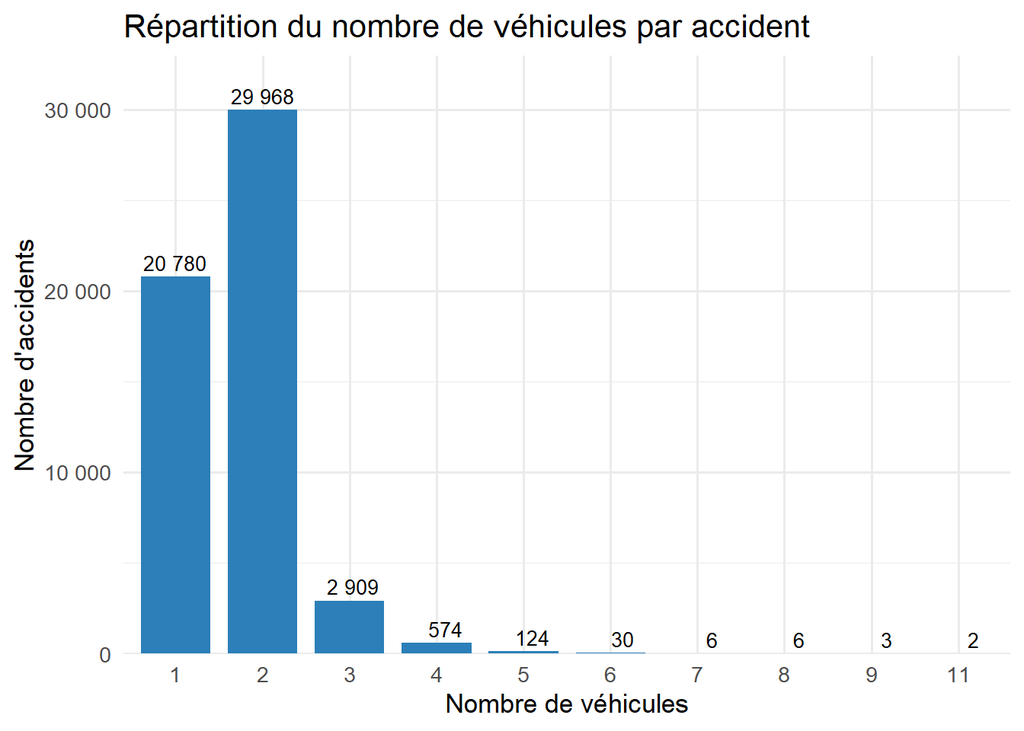

```r
library(ggplot2)
library(scales)
veh <- data.frame(
  Nb_vehicules = c(1, 2, 3, 4, 5, 6, 7, 8, 9, 11),
  Nb_accidents = c(20780, 29968, 2909, 574, 124, 30, 6, 6, 3, 2)
)

ggplot(veh, aes(x = factor(Nb_vehicules), y = Nb_accidents)) +
  geom_col(fill = "#2C7FB8", width = 0.8) +
  geom_text(aes(label = format(Nb_accidents, big.mark = " ")),
            vjust = -0.4, size = 3.5) +
  scale_y_continuous(labels = label_number(big.mark = " "),
                     expand = expansion(mult = c(0, 0.1))) +
  labs(title = "Répartition du nombre de véhicules par accident",
       x = "Nombre de véhicules", y = "Nombre d'accidents") +
  theme_minimal(base_size = 13)
```

*Interprétation statistique* - 29 968 accidents impliquent deux véhicules, soit environ 55,1 %. - 20 780 accidents impliquent un seul véhicule, soit environ 38,2 %. - Les accidents impliquant trois véhicules ou plus représentent environ 6,7 %. La majorité des accidents corporels recensés impliquent donc un ou deux véhicules.

*Attention* : cette répartition décrit les accidents corporels enregistrés, pas le risque d’accident selon le nombre de véhicules.

```r
summary(accidents$nb_vehicules)
```

```
##    Min. 1st Qu.  Median    Mean 3rd Qu.    Max.
##   1.000   1.000   2.000   1.704   2.000  11.000
```

La moyenne est de 1,704 véhicule par accident. La médiane est de 2 véhicules. La moitié des accidents implique au maximum deux véhicules. Quelques accidents impliquent un nombre beaucoup plus élevé de véhicules, jusqu’à 11.

```r
names(accidents)
```

```
##  [1] "Num_Acc"           "jour"              "mois"
##  [4] "an"                "hrmn"              "lum"
##  [7] "dep"               "com"               "agg"
## [10] "int"               "atm"               "col"
## [13] "adr"               "lat"               "long"
## [16] "nb_usagers"        "grave"             "tue"
## [19] "date"              "heure"             "minute"
## [22] "periode"           "nb_Adultes"        "nb_Jeunes adultes"
## [25] "nb_Seniors"        "nb_Adolescents"    "nb_Adultes mûrs"
## [28] "nb_Enfants"        "nb_vehicules"
```

```r
dim(accidents)
```

```
## [1] 54402    29
```

*Pour mieux voir les 29 variables*

```r
library(knitr)

groupes <- data.frame(
  Groupe = c("Identification", "Temps", "Caractéristiques de l'accident",
             "Gravité et usagers", "Véhicules"),
  Variables = c("Num_Acc",
                "jour, mois, an, hrmn, date, heure, minute, periode",
                "lum, dep, com, agg, int, atm, col, adr, lat, long",
                "nb_usagers, grave, tue, les 6 variables de classes d'âge",
                "nb_vehicules")
)

kable(groupes, caption = "Groupes de variables du jeu de données")
```

Groupes de variables du jeu de données

| Groupe | Variables |
| --- | --- |
| Identification | Num_Acc |
| Temps | jour, mois, an, hrmn, date, heure, minute, periode |
| Caractéristiques de l’accident | lum, dep, com, agg, int, atm, col, adr, lat, long |
| Gravité et usagers | nb_usagers, grave, tue, les 6 variables de classes d’âge |
| Véhicules | nb_vehicules |

*Controle finale des valeurs manquantes*

```r
colSums(is.na(accidents))
```

```
##           Num_Acc              jour              mois                an
##                 0                 0                 0                 0
##              hrmn               lum               dep               com
##                 0                 0                 0                 0
##               agg               int               atm               col
##                 0                 0                 0                 0
##               adr               lat              long        nb_usagers
##                 2                 0                 0                 0
##             grave               tue              date             heure
##                 0                 0                 0                 0
##            minute           periode        nb_Adultes nb_Jeunes adultes
##                 0                 0                 0                 0
##        nb_Seniors    nb_Adolescents   nb_Adultes mûrs        nb_Enfants
##                 0                 0                 0                 0
##      nb_vehicules
##                 0
```

*Bilan de la table accidents* - 54 402 accidents. - 29 variables. - 2 valeur manquante. - 0 doublon sur Num_Acc. - Les classes d’âge sont intégrées. - Le nombre de véhicules est intégré. - Les indicateurs de gravité sont intégrés.

```r
nrow(accidents)
```

```
## [1] 54402
```

```r
n_distinct(accidents$Num_Acc)
```

```
## [1] 54402
```

```r
sum(duplicated(accidents$Num_Acc))
```

```
## [1] 0
```

*Examiner les modalités présentes*

```r
table(accidents$lum, useNA = "ifany")
```

```
##
##     1     2     3     4     5
## 35580  3599  6101   623  8499
```

pas de valeur manquante ou de code -1